# Chapitre 8

## Le futur se trace

Manœuvrer dans le digital avec les cartes de Wardley

Le futur se trace

Manœuvrer dans le digital avec les cartes de Wardley

Olivier Wulveryck

# Chapitre 8 : De la liste à la carte - Visualiser votre chaîne de valeur

## Introduction

Souvenez-vous du **théâtre de la stratégie** décrit dans l’introduction de ce livre. L’absence d’un langage commun transforme chaque débat stratégique en bataille de territoires. Nous avions fait une promesse : vous équiper d’outils qui dépassionnent le débat.

### Les limites des outils actuels

Les outils traditionnels (listes de tâches, matrices 2×2, diagrammes d’architecture) structurent notre pensée mais nous enferment. Les matrices et tableaux de bord créent l’illusion du déterminisme : mêmes critères, même résultat. Cela rassure en comité mais transforme chaque débat en bataille pour « la bonne case ».

Les diagrammes d’architecture montrent les actifs techniques mais pas la valeur. On y voit les composants, pas leur lien avec le besoin utilisateur. On y voit l’état présent, pas le mouvement possible.

La stratégie n’est pas un problème algorithmique. C’est un problème **heuristique**[^1] qui mobilise l’expérience, l’intuition et le jugement humain pour naviguer dans l’incertitude.

### Pourquoi deux axes sont nécessaires

Au **chapitre 5**, nous avons découvert l’**évolution** : tout composant technologique suit une trajectoire en quatre phases, de la genèse vers la commodité. Cette compréhension est précieuse : elle nous donne un sens et une consistance du mouvement.

Mais un axe seul ne fait pas une carte. Un navigateur qui connaîtrait les courants mais n’aurait aucune étoile pour s’orienter saurait *comment* les choses bougent, mais pas *pourquoi* aller dans une direction plutôt qu’une autre.

La pièce manquante ? Le **repère**. Les navigateurs utilisent l’étoile polaire non comme une destination, mais comme un **point fixe** pour s’orienter. Le repère que nous cherchons est l’**utilisateur et son besoin** (le point stable autour duquel tout s’organise).

**Attention :** À ne pas confondre avec la « North Star Metric » du *Growth Hacking*[^2], qui désigne un objectif chiffré, pas un repère fixe.

### La carte comme antidote au théâtre

Ce dont nous avons besoin, c’est d’une représentation qui intègre l’évolution pour situer chaque composant sur sa trajectoire, qui se repère sur l’utilisateur pour ne jamais perdre de vue la valeur, qui révèle les dépendances pour comprendre les articulations, et qui favorise l’heuristique en offrant un terrain où le jugement peut s’exercer.

Cette représentation existe : la **Carte de Wardley**[^3]. Soyons clairs d’emblée : ce n’est pas une représentation parfaite.

Sa vertu première ? Dépassionner le débat. En offrant un langage commun et une représentation visuelle, elle déplace la conversation du « qui a raison ? » vers « qu’observons-nous ensemble ? ». Les idées sont jugées sur leur pertinence, pas sur le statut de qui les propose.

Dans ce chapitre, nous allons apprendre à construire cette carte comme un **langage visuel** qui transforme une liste en paysage stratégique.

## Ce qu’une carte de Wardley n’est PAS (avant de commencer)

Avant d’apprendre à construire une carte, clarifions ce qu’elle n’est **pas**. Car les malentendus sont fréquents, et ils conduisent à des frustrations inutiles.

### Pas un diagramme d’architecture

Un diagramme d’architecture montre les **actifs** (les serveurs, les services, les bases de données, les flux de données). Il répond à la question : « comment ça marche ? » Mais rappelons-nous la leçon du **chapitre 7** : ces actifs sont souvent des passifs déguisés. Le diagramme d’architecture représente les composants, pas nécessairement la valeur qu’ils créent.

Une carte de Wardley montre la **valeur et le mouvement**. Elle répond aux questions : « pourquoi ces composants existent-ils ? », « quelle valeur délivrent-ils à l’utilisateur ? », « où vont-ils dans leur évolution ? »

Un diagramme d’architecture est **statique** : il capture un état technique à un instant T. Une carte est **dynamique** : elle intègre le mouvement, les forces, les transitions.

Vous pouvez avoir un diagramme d’architecture magnifique (propre, documenté, à jour) et rester aveugle aux menaces stratégiques. Vous ne verrez pas que ce composant que vous avez développé en interne est en train d’être commoditisé par un concurrent. Vous ne verrez pas que cette dépendance critique est coincée en phase de genèse (instable, coûteuse, risquée).

La carte et le diagramme d’architecture sont complémentaires, pas substituables.

### Pas un Gantt

Un diagramme de Gantt a un **axe temporel** : il montre quand les tâches commencent, combien de temps elles durent, quand elles se terminent. C’est un outil de planification.

Une carte de Wardley n’a **pas d’axe temporel**. L’axe horizontal (évolution) ne mesure pas des semaines ou des mois. Il mesure la **maturité** : où en est un composant dans son parcours de la genèse à la commodité. Souvenez-vous de ce que nous avons établi au **chapitre 5** : l’évolution n’a pas de temporalité fixe. Un composant peut rester en genèse pendant une décennie si les conditions ne sont pas réunies, puis basculer en commodité en quelques années sous l’effet d’une disruption technologique ou d’un changement réglementaire. Ce parcours peut prendre cinq ans ou vingt ans selon la dynamique du secteur.

Une carte est un **instantané** (une photo prise à un instant donné). Si vous la redessinez dans six mois, les positions auront bougé. Certains composants auront glissé vers la droite (commoditisation). D’autres, nouveaux, seront apparus à gauche (innovation émergente).

Cette notion d’**instantané daté** rend la carte utile. Une carte porte toujours implicitement une date : « janvier 2025 ». Elle ne dit pas « cela prendra trois mois ». Elle dit « voici où nous sommes aujourd’hui, voici les forces en présence, à vous de juger à quelle vitesse cela va bouger ». La carte ne prédit pas le futur : elle documente le présent de manière à ce que le jugement humain puisse s’exercer.

Le Gantt **rassure** par sa précision (même illusoire). La carte **provoque** par son incertitude assumée.

### Ni vérité absolue, ni outil descendant

Une carte est une **perspective**, pas un oracle.

Deux équipes, face au même système, dessineront des cartes différentes. Et c’est normal. Leurs questions stratégiques diffèrent. Leurs contextes diffèrent. Leurs hypothèses sur l’évolution des composants diffèrent.

L’important n’est pas d’avoir raison dans l’absolu. L’important est de **rendre explicites** les hypothèses implicites qui guident vos décisions. Quand vous positionnez un composant en « produit » plutôt qu’en « commodité », vous dites : « je crois que ce composant n’est pas encore standardisé au point de devenir interchangeable ». C’est une hypothèse. Discutable. Testable. Révisable.

Le piège serait de traiter la carte comme un **outil de décision algorithmique** (« puisque ce composant est ici, alors nous devons faire cela »). Non. La carte est un **support pour l’heuristique humaine** : elle organise l’information de manière à nourrir le jugement, l’intuition, l’expérience des décideurs.

Méfiez-vous aussi de la tentation inverse : utiliser la carte comme un **document de présentation figé** (un PowerPoint stratégique que l’on déroule en comité). Si la carte a été construite seul dans votre bureau, puis présentée à l’équipe comme une vérité révélée, vous avez reproduit le théâtre de la stratégie avec un nouvel accessoire. La carte est un **outil de conversation**. Elle se construit collectivement, en atelier, en débat. Les désaccords ne sont pas des *bugs*, ce sont des *features* : ils révèlent des différences de perception qu’il faut aligner.

## Anatomie d’une carte de Wardley

Avant de plonger dans la construction de votre première carte, comprenons ce qui la compose. Une carte de Wardley repose sur une architecture simple mais puissante : **deux axes, un repère, des composants et leurs relations**.

### Le repère : l’utilisateur et son besoin

Toute carte commence par un point fixe, le **repère** : l’utilisateur et son besoin. Non pas un utilisateur abstrait, mais celui dont le besoin justifie l’existence de votre système. C’est lui qui donne son sens à tout ce qui suit. Ce principe n’est pas nouveau : nous l’avons rencontré au **chapitre 3** parmi les doctrines universelles : « Connaître vos utilisateurs et leurs besoins » était le premier principe de la phase I, celui qui fonde tout le reste. La carte de Wardley ne fait que formaliser visuellement ce que nous savions déjà être fondamental.

Ce repère n’est pas une métrique à atteindre (rappelons-nous la confusion autour de la « North Star Metric »). C’est un **point de référence stable**. Pendant que tout le reste évolue, se transforme et migre sur la carte, le besoin utilisateur reste le nord qui oriente la navigation.

On ne construit pas une stratégie pour optimiser un indicateur. On la construit pour servir un besoin réel.

Sur la carte, ce repère se place en haut, **visible**, car c’est la raison d’être du système. Tout le reste découle de là.

### L’axe vertical : la chaîne de valeur

Du besoin utilisateur descend une cascade de composants qui, ensemble, permettent de le satisfaire. C’est la **chaîne de valeur** (l’axe vertical de la carte).

Cet axe ne mesure pas une métrique quantitative. Il exprime la **proximité avec le besoin utilisateur**. Plus un composant est haut sur la carte, plus il est visible de l’utilisateur final. Plus il descend, plus il devient invisible, enfoui dans les couches techniques qui supportent l’ensemble.

Prenons un exemple simple : un utilisateur qui utilise une application mobile de navigation. **En haut**, pleinement visible, l’itinéraire affiché sur l’écran (ce que l’utilisateur perçoit directement). **Plus bas**, invisible pour lui mais essentiel au service, le moteur de calcul d’itinéraire qui trace le chemin optimal. **Encore plus bas**, les données cartographiques qui alimentent ce moteur. **Tout en bas**, totalement invisible, l’infrastructure cloud qui héberge l’ensemble du service.

Chaque niveau **dépend** du niveau inférieur. Pas de calcul sans données. Pas de données sans infrastructure. La chaîne de valeur révèle ces dépendances structurelles.

**Note:** La position verticale représente en réalité le nombre de « sauts » entre un composant et le besoin utilisateur. Nous reviendrons sur cette nuance dans la section « Pour aller plus loin ».

### L’axe horizontal : l’évolution

Comme nous l’avons vu au **chapitre 5**, tout composant technologique traverse des **phases d’évolution**, de l’émergence initiale vers la standardisation complète. L’axe horizontal de la carte représente cette maturation inéluctable : quatre phases étiquetées par facilité **genèse, sur mesure (ou *custom*), produit, et commodité**.

Positionner un composant sur cet axe, c’est répondre à une question stratégique : **où en est ce composant dans son parcours évolutif ?** Cette position détermine comment on doit le gérer, l’acheter, le construire ou le vendre. Un composant en genèse justifie l’investissement interne et l’expertise spécialisée. Un composant en commodité s’achète au meilleur prix, sans état d’âme.

### Les composants et leurs liens

Une carte n’est pas une liste. C’est un **réseau**. Chaque composant de la chaîne de valeur est lié aux autres par des relations de dépendance : ce composant a besoin de celui-là pour fonctionner (et on parle ici de besoin fondamental, sans sa dépendance, le composant ne fonctionne plus).

Ces liens révèlent les fragilités du système. Un composant critique, situé en position de genèse (instable, rare, coûteux) dont dépendent de nombreux autres, signale un risque. Un composant en cours de commoditisation rapide, sur lequel vous avez investi des efforts de différenciation, signale un gaspillage imminent.

La carte transforme l’invisible en visible : les dépendances ne sont plus des suppositions, des connaissances tacites dispersées dans les têtes. Elles deviennent des traits sur un terrain partagé, discutables, questionnables. Ces éléments (repère, axes, composants, liens) ne forment pas un schéma statique : ils créent un **espace de représentation** où l’heuristique humaine peut s’exercer.

Armés de cette compréhension de l’anatomie d’une carte, construisons-en une. Pas sur un cas théorique, mais sur un terrain actuel, vivant, traversé par des forces économiques puissantes : le développement logiciel assisté par l’intelligence artificielle.

## Atelier pratique : cartographier le développement assisté par IA

Plaçons-nous dans la peau d’un décideur technologique en 2025. L’intelligence artificielle générative a bouleversé le paysage du développement logiciel. Des outils comme Claude Code, GitHub Copilot ou Cursor promettent de décupler la productivité des développeurs. Les API de modèles de langage se commoditisent à vitesse grand V. Dans ce contexte mouvant, comment décider où investir ? Quelles compétences cultiver ? Quels outils adopter ou construire ?

Une liste de composants ne suffit pas. Une matrice « impact/maturité » réduirait cette complexité à des cases trompeuses. Construisons plutôt une carte.

### Étape 1 : identifier le besoin utilisateur et définir le scope

Commençons par **le repère**. Qui est l’utilisateur final ? Quel est son besoin ?

Dans notre cas, l’utilisateur est quelqu’un (un client, un collaborateur interne, un citoyen) qui a **un problème à résoudre** et qui attend **une solution numérique fonctionnelle**. Il ne se soucie pas du langage de programmation utilisé, ni de l’infrastructure cloud sous-jacente, ni même du fait que le code ait été écrit avec ou sans assistance IA. Il veut que ça marche, que ça soit fiable, que ça réponde à son besoin.

Ce besoin (« une solution numérique à mon problème ») devient le repère en haut de notre carte. C’est notre nord.

Maintenant, définissons le **scope**. Allons-nous cartographier l’intégralité du système, depuis la fabrication des serveurs jusqu’au design de l’interface utilisateur ? Non. Une carte utile est une carte **ciblée**. Nous ne cartographions que ce qui est pertinent pour la question stratégique que nous nous posons.

Ici, notre question pourrait être : *« Comment structurer notre capacité de développement logiciel dans un monde où l’IA générative devient omniprésente ? »*

Nous allons donc nous concentrer sur la **chaîne de valeur du développement logiciel**, depuis le besoin utilisateur jusqu’aux composants technologiques qui permettent de coder, tester, déployer.

Où s’arrêter ? Définissons un **critère d’arrêt** : nous descendons la chaîne de valeur jusqu’aux composants que **nous ne contrôlons pas directement**. Les LLM APIs (OpenAI, Anthropic, Google, AWS, …) ? Nous les consommons, nous ne les construisons pas. L’infrastructure cloud (AWS, Azure) ? Pareil. Ce sont des commodités que nous achetons. Nous nous arrêtons là.

### Étape 2 : construire la chaîne de valeur (axe vertical)

Partons du repère (le besoin utilisateur) et descendons. Quels sont les composants nécessaires pour délivrer cette solution numérique ?

Au sommet, directement visible par l’utilisateur final, se trouve le **besoin lui-même** : une solution numérique fonctionnelle qui résout son problème. Ce besoin se matérialise dans une **application ou un service** (le logiciel déployé qu’il utilise au quotidien). Juste en dessous, encore relativement proche de la surface mais déjà moins visible, vit le **code source** : le code applicatif qui fait tourner ce service.

Ce code ne s’écrit pas seul. Il repose sur le *software craftsmanship*[^4], cette expertise humaine qui englobe l’architecture logicielle, les *design patterns*, la compréhension profonde du métier, cette capacité rare à traduire un problème complexe en code élégant. Cette expertise s’appuie aujourd’hui massivement sur les **outils de développement assisté par IA** comme Claude Code, GitHub Copilot ou Cursor (des agents qui assistent le développeur dans l’écriture, le débogage, la révision de code).

Ces outils eux-mêmes s’intègrent dans une **infrastructure de développement** plus large : Git pour le contrôle de version, GitHub ou GitLab pour la collaboration, les pipelines CI/CD comme GitHub Actions ou Jenkins pour automatiser tests et déploiements. Tout ce travail technique baigne dans un océan de **communautés et ressources** (Stack Overflow, documentation open source, forums, tutoriels), ce capital social accumulé par des millions de développeurs à travers le monde.

Parallèlement, toute cette chaîne doit satisfaire aux exigences de **compliance et sécurité** : politiques de code review, outils de *security scanning* comme Snyk ou Dependabot[^5], respect des réglementations telles que le RGPD[^6] ou des cadres d’audit de sécurité comme SOC2[^7]. En profondeur, totalement invisibles pour l’utilisateur final, les **LLM APIs** (Claude, GPT, Gemini) alimentent les outils d’assistance IA. Et tout au fond, soutenant l’ensemble de l’édifice, l’**infrastructure cloud** fournit *compute*, *storage* et *networking* via AWS, Azure ou GCP.

Chaque niveau **dépend** du suivant. Pas de logiciel sans code. Pas de code efficace sans expertise humaine. Cette expertise s’appuie sur des outils d’assistance IA, qui eux-mêmes consomment des LLM, qui tournent sur une infrastructure cloud.

Remarquez que cette liste n’est pas exhaustive. Nous aurions pu inclure le monitoring, les bases de données, les frameworks applicatifs. Mais nous avons choisi ce périmètre car il répond à notre question : *comment l’IA transforme-t-elle notre capacité de développement ?*

**Le contexte détermine le scope.** Une autre organisation, avec une autre question stratégique, dessinerait une carte différente.

**Erreur courante à éviter : trop de composants**

Vous êtes tenté de lister 40, 50 composants pour être exhaustif ? Résistez. Une carte utile contient **10-20 composants maximum**. Au-delà, elle devient illisible et contre-productive.

Si vous dépassez largement ce seuil, c’est un signal : soit votre scope est trop large (vous voulez tout cartographier d’un coup), soit vous mélangez plusieurs niveaux de zoom (stratégique + opérationnel). Redéfinissez votre question stratégique. Zoomez in ou out. Regroupez les composants similaires. Simplifiez impitoyablement.

Une carte est un outil de conversation, pas un inventaire exhaustif.

### Étape 3 : positionner sur l’axe d’évolution (axe horizontal)

Maintenant que nous avons notre chaîne de valeur, positionnons chaque composant sur l’axe d’**évolution**. Appliquons les quatre stades décrits au **chapitre 5** : genèse, custom, produit, commodité.

Commençons par le haut. La **solution numérique** elle-même reste en phase **custom** : chaque application est unique, façonnée pour un besoin spécifique. Même si elle utilise des composants standards, l’assemblage final reste sur-mesure. Le **code source** qui la compose se situe quelque part entre **custom et produit** (une nuance importante). Le code peut être écrit de manière monolithique, étroitement couplé au problème, auquel cas il reste custom. Mais il peut aussi être architecturé en modules réutilisables, avec des API claires, pensé comme un produit interne. C’est un **choix stratégique**, pas un hasard.

Le **software craftsmanship** suit une trajectoire similaire, entre **custom et produit**. L’expertise du développeur commence artisanale : chaque problème demande une solution créative. Mais avec le temps, certaines pratiques se codifient : *design patterns*, principes SOLID, architecture hexagonale[^8]. L’artisanat devient méthode reproductible.

Les **outils de développement assisté par IA** se positionnent déjà en phase **produit**. GitHub Copilot, Cursor, Claude Code[^9] : ces outils sont sortis de la genèse entre 2021 et 2025 et se sont productisés rapidement. Ils sont maintenant des offres commerciales stables, documentées, avec des API et des intégrations. Ils ne sont pas encore des commodités (pas interchangeables, pas gratuits ou quasi-gratuits) mais ils évoluent vite dans cette direction.

L’**infrastructure de développement** glisse de **produit vers commodité**. Git[^10] est une commodité : open source, omniprésent, gratuit. GitHub Actions se commoditise progressivement (standardisé, payant mais abordable, facile à remplacer par GitLab CI ou CircleCI). Jenkins, plus ancien, est déjà largement commoditisé, déployable partout en open source. Les **communautés et ressources** (Stack Overflow, documentation open source, tutoriels YouTube) sont déjà en pleine **commodité** : librement accessibles, abondantes, standardisées. C’est un bien commun, une commodité sociale.

La **compliance et sécurité** présente un visage dual, entre **custom et produit**. Les politiques de sécurité sont souvent *custom-built* (chaque entreprise a ses propres règles). Mais les outils de scanning comme Snyk, Dependabot ou les solutions SAST/DAST (*Static/Dynamic Application Security Testing*) sont des produits, voire des commodités émergentes. La partie outil se commoditise ; la partie politique reste custom.

Enfin, tout au fond de la chaîne, les **LLM APIs** traversent une **commoditisation accélérée**[^11]. Voici un mouvement rapide : en 2023, accéder à GPT-4 était presque de la genèse (réservé aux *early adopters*, coûteux, instable). En 2025, les APIs de LLM sont abondantes : OpenAI, Anthropic, Google, Mistral, Meta. Les prix chutent. Les performances convergent. L’**infrastructure cloud** (AWS, Azure, GCP) est déjà en pleine **commodité**. Compute, storage, networking sont standardisés, interchangeables avec quelques frictions certes, faciles à consommer. C’est le prototype même de l’*utility*.

**Erreur courante à éviter : confondre « fait maison » avec « custom »**

Le stade d’évolution d’un composant ne dépend pas de **qui** l’a construit, mais de **comment** il est construit. Un développement interne peut être en phase **custom** s’il s’agit d’un monolithe couplé étroitement au problème, difficile à réutiliser. Il peut être en phase **produit** s’il est architecturé en modules avec des API claires, pensé pour être réutilisable. Il peut même être une **commodité** s’il s’agit d’un composant générique que vous auriez pu acheter ailleurs.

Posez-vous la question : « Si je devais vendre ce composant à d’autres organisations, serait-ce possible ? » Si oui, c’est un produit (ou proche). Sinon, demandez-vous pourquoi : trop spécifique (custom), ou trop générique et déjà commoditisé ailleurs ?

**Décision stratégique majeure** : Choisir consciemment de développer en « mode produit » plutôt qu’en « mode custom » (même pour du code interne). Cela change tout : architecture, documentation, tests, évolutivité.

### Étape 4 : identifier les types de capitaux

Tous ces composants ne sont pas de même nature. Certains sont technologiques, d’autres humains, d’autres encore sociaux. Cette distinction est importante car elle influence comment on les acquiert, les cultive, les protège.

Appliquons le **cadre des capitaux** présenté au **chapitre 7**. Dans notre carte du développement assisté par IA, identifions les différents types d’actifs :

**Capital de connaissance :** Le *software craftsmanship* (cette expertise humaine qui, même à l’ère de l’IA, reste cruciale pour architecturer un système, comprendre les besoins métier, faire les bons compromis techniques).

**Capital social :** Les **communautés et ressources** (Stack Overflow, forums, documentation open source). Ce capital accumulé par des millions de développeurs ne s’achète pas, il se cultive.

**Capital technologique :** Les outils d’IA, l’infrastructure de développement, les LLM APIs, l’infrastructure cloud. Ce capital évolue rapidement : ce qui est un avantage aujourd’hui devient un coût d’entrée demain.

**Capital réglementaire :** La **compliance et sécurité** (certifications, conformité RGPD ou SOC2, processus de sécurité).

Comme nous l’avons vu au chapitre 7, chaque type de capital évolue à son rythme. Cette compréhension guide les décisions d’investissement : **investissez massivement sur les capitaux qui évoluent lentement et sont difficiles à copier, achetez ceux qui se commoditisent rapidement**.

### Étape 5 : analyser le mouvement

Notre carte est maintenant tracée. Mais une carte statique n’a que peu de valeur stratégique. Ce qui importe, c’est le **mouvement** : où vont les composants, quelles forces les poussent, quelles conséquences pour notre organisation.

Observons les dynamiques à l’œuvre :

**Les LLM se commoditisent à vitesse grand V.** Ce qui était un avantage compétitif en 2023 (« nous avons accès à GPT-4 ») ne l’est plus en 2025. Tous vos concurrents ont accès aux mêmes APIs, aux mêmes capacités. Implication stratégique : **ne misez pas votre différenciation sur l’accès aux LLM**. Ils deviennent un coût d’entrée, pas un avantage.

**Les outils agentiques se productisent rapidement.** Claude Code, GitHub Copilot évoluent de la genèse vers le produit. Ils deviennent stables, fiables, accessibles. Implication : **adoptez-les maintenant**, avant qu’ils ne deviennent des commodités et que ne pas les utiliser devienne un désavantage. Mais sauf si vous êtes un géant mondial de la tech, ne construisez pas votre propre outil concurrent : vous arrivez trop tard dans la course.

**Le software craftsmanship reste un capital différenciant.** Malgré l’IA, l’expertise humaine ne se commoditise pas (encore). Savoir architecturer un système résilient, comprendre les besoins métier non exprimés, faire les bons compromis techniques : cela reste artisanal, sur mesure, difficile à reproduire. Implication : **investissez massivement dans ce capital de connaissance**. Formez vos équipes, cultivez une culture d’ingénierie exigeante, attirez les meilleurs talents.

**Mais attention : le code sur mesure peut devenir un boulet.** Si votre code est un monolithe étroitement couplé, écrit sans réutilisabilité en tête, vous accumulez de la dette technique (de la masse inerte). Une décision stratégique : architecturer votre code en **mode produit** (modules, APIs claires, documentation) même si c’est du développement interne. Cela transforme un actif sur mesure en un actif produit (plus flexible, plus évolutif).

**Le capital social devient stratégique.** Les communautés de développeurs, l’open source, les réseaux professionnels ne sont pas des « *nice to have* ». Dans un monde où les outils se commoditisent, l’accès aux bonnes personnes, aux bonnes pratiques, aux innovations émergentes fait la différence. Implication : **contribuez activement** aux communautés (open source, conférences, publications techniques). Le retour sur investissement est diffus mais réel.

La carte révèle les questions stratégiques essentielles. **Où investir ?** Sur le *software craftsmanship* (capital de connaissance) et le capital social. Pas sur la construction d’outils IA sur mesure : trop tard, ils se commoditisent déjà. **Quels composants vont bouger ?** Les LLM APIs et les outils agentiques glissent vers la droite, vers la commoditisation. Anticipez ce mouvement : ne verrouillez pas votre architecture sur un fournisseur spécifique. **Où sont les risques ?** Si vos développeurs ne maîtrisent pas les outils IA, vous prenez du retard (capital de connaissance insuffisant). Si votre code est un monolithe sur mesure, vous ralentissez (dette technique).

Une carte n’est pas une boule de cristal. Elle ne prédit pas l’avenir. Mais elle **organise votre perception** du présent de manière à rendre le mouvement visible, et donc discutable, questionnable, actionnable.

**Erreur courante à éviter : traiter la carte comme figée**

Vous êtes tenté de passer des semaines à perfectionner chaque position au pixel près ? Résistez. Une carte est un *snapshot* d’un paysage en mouvement. Elle sera obsolète dans six mois.

Ce qui compte n’est pas la perfection de la carte, mais la **conversation** qu’elle génère pendant sa construction, les **décisions** qu’elle éclaire immédiatement, l’**apprentissage** qu’elle provoque dans l’équipe.

Tracez vite. Débattez. Décidez. Agissez. Puis redessinez dans quelques mois. La carte est un brouillon itératif, pas une œuvre d’art définitive. Mieux vaut une carte imparfaite qui provoque le débat qu’une carte parfaite qui arrive trop tard.

Voici à quoi ressemble notre carte complète du développement assisté par IA :

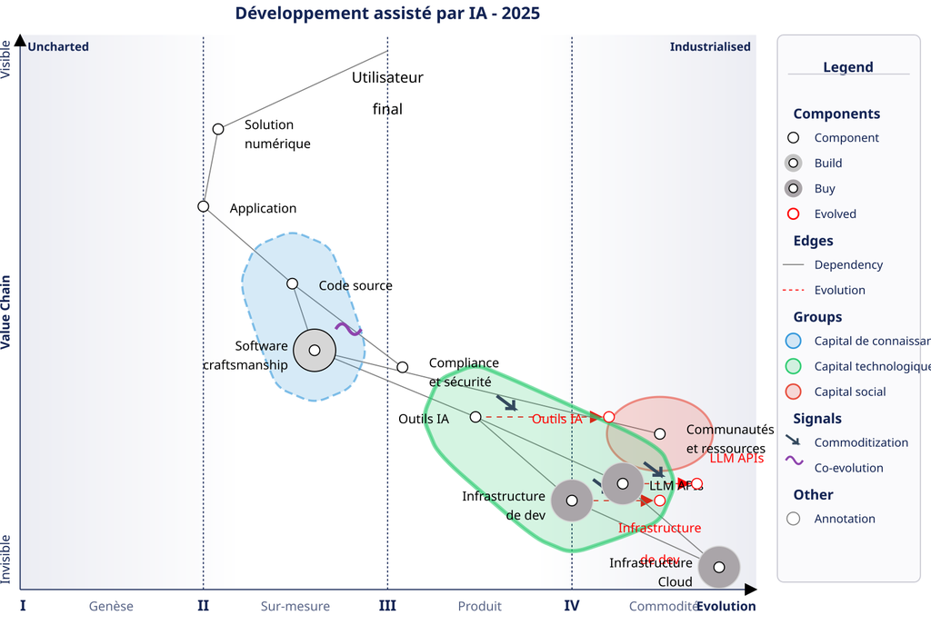

**Point crucial :** cette carte n’est pas une vérité universelle. C’est **une perspective** (celle de l’auteur, dans ce contexte, à ce moment donné). Peut-être pensez-vous que le software craftsmanship se commoditise déjà avec l’IA, ou que les LLM APIs restent des produits différenciés plutôt que des commodités. Ce désaccord n’est pas un problème : c’est précisément ce qu’une carte co-construite en équipe rendrait visible, discutable, et résolvable.

### Exemple 2 : la librairie indépendante lance l’e-commerce

Changeons complètement de contexte pour montrer que la cartographie s’applique partout. Plaçons-nous dans la peau d’une librairie indépendante qui veut lancer un service de vente en ligne pour concurrencer Amazon et les grandes chaînes.

#### Le repère et le scope

**Repère :** Un client qui cherche un livre et veut l’acheter facilement

**Scope :** La chaîne de valeur de la vente en ligne, du besoin client jusqu’aux composants que nous ne contrôlons pas (plateformes, hébergeurs)

**Question stratégique :** *« Où investir nos ressources limitées pour créer une expérience différenciante ? »*

#### La chaîne de valeur

Partons du besoin client et descendons. Au sommet, pleinement visible, se trouve le **besoin client** lui-même : trouver et acheter un livre facilement. Ce besoin se concrétise dans l’interface de **commande en ligne** (recherche, panier, achat). Cette interface s’appuie sur un **catalogue numérique** qui décrit les livres, affiche leur disponibilité, propose des recommandations. Parallèlement, hautement visible également, le **conseil personnalisé** apporte la touche humaine : sélection éditoriale, avis du libraire, événements culturels.

#### Positionnement sur l’axe d’évolution

L’interface de **commande en ligne** se situe en phase **produit** : les patterns sont connus, les interfaces standardisées. Le **catalogue numérique** oscille entre **sur mesure et produit** : notre sélection est unique, mais le format reste standard. Le **conseil personnalisé**, cœur de notre différenciation, se trouve quelque part entre **genèse et custom** : c’est notre expertise unique, artisanale, impossible à reproduire industriellement. Le **stock physique** reste en phase **custom**, spécifique à notre boutique.

En revanche, le **système de paiement** est déjà une **commodité** complète : Stripe, PayPal, des solutions standardisées et abondantes. La **solution e-commerce** glisse de **produit vers commodité** : Shopify[^12] se commoditise rapidement. La **logistique** est en pleine **commodité** : transporteurs standardisés, interchangeables. L’**hébergement web** est également une **commodité** aboutie : OVH, AWS, des utilities banalisées.

#### Insights stratégiques révélés par la carte

La carte révèle immédiatement où **ne pas** investir : toute la couche technologique. Le système de paiement ? Une commodité, utilisons Stripe ou PayPal. La plateforme e-commerce ? Une commodité émergente, Shopify suffit largement. L’hébergement ? Une commodité complète, prenons le moins cher qui fonctionne. La décision s’impose d’elle-même : aucun développement technique sur mesure. Tout acheter en commodité.

À l’inverse, la carte crie où investir massivement : le **conseil personnalisé**. C’est en phase de genèse ou sur mesure : notre expertise unique. C’est hautement visible pour le client, la valeur est perçue directement. C’est impossible à copier par Amazon, un avantage compétitif durable. La décision découle naturellement : créer du contenu (vidéos, articles, événements en ligne), développer des recommandations personnalisées, raconter l’histoire des livres.

Le **catalogue numérique** apparaît comme un point d’équilibre subtil. Sur mesure dans le fond (notre sélection est unique) mais produit dans la forme (les standards du web). L’implication est claire : investir sur la curation (quels livres, pourquoi) pas sur la technologie de présentation.

Le **stock physique** révèle une opportunité cachée. Notre stock est sur mesure, unique (livres rares, éditions spéciales) mais il reste « moins visible » sur la carte. La décision émerge : le rendre plus visible ! Créer une fonctionnalité « Visite virtuelle du stock » qui expose notre richesse physique aux clients en ligne.

Sans la carte, l’approche classique consisterait à investir dans une plateforme e-commerce sur mesure pour « se différencier technologiquement ». Pure perte : on réinventerait une commodité. Avec la carte, la vérité saute aux yeux : acheter toute la technologie (déjà commoditisée[^13]) et investir toute l’énergie sur ce qui reste en genèse ou custom. Nous ne sommes pas une entreprise technologique. Nous sommes une entreprise de conseil culturel qui utilise la technologie, commoditisée.

Voici à quoi ressemble notre carte de la librairie indépendante :

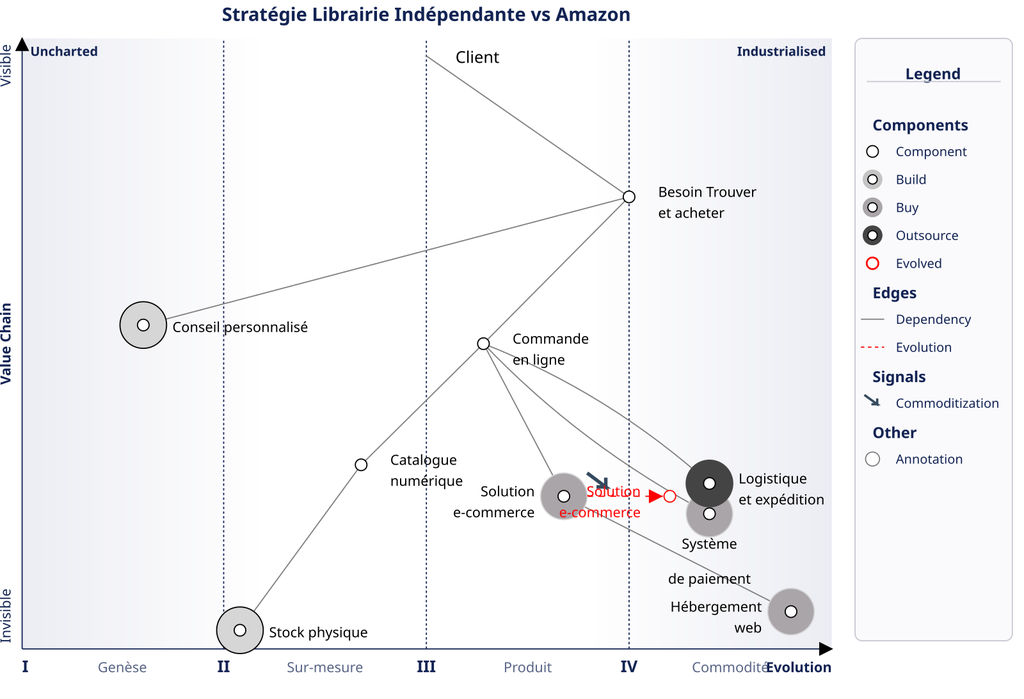

La carte révèle visuellement la stratégie : investir massivement à gauche (genèse/custom) où nous avons un avantage compétitif unique, acheter tout à droite (commodité) où nous n’avons aucune différenciation possible.

## Passer à l’action

Vous venez de voir deux exemples complets. Voici la méthode reproductible pour créer votre propre carte.

### Avant de commencer (5 minutes)

**Matériel :** Tableau blanc + marqueurs OU outil numérique (OnlineWardleyMaps, ou Miro) **Équipe :** 3-5 personnes concernées par la question stratégique **Question claire :** Formuler LA question à laquelle la carte doit répondre

#### 1. Identifier le repère (5 min)

Qui est l’utilisateur final ? (personne réelle, pas « le marché ») Quel est son besoin précis ? (1 phrase max) Écrire en haut du tableau : **« Utilisateur : [besoin] »**

**Erreur courante :** Commencer par les composants techniques. Toujours partir du besoin utilisateur.

#### 2. Définir le scope (5 min)

Quelle partie du système allez-vous cartographier ? Où vous arrêtez-vous ? (Critère : composants que vous ne contrôlez pas) Documenter : « Cette carte couvre [scope] pour répondre à [question] »

**Erreur courante :** Scope trop large (vouloir tout montrer). Restez focalisé.

#### 3. Lister les composants (10 min)

Brainstorming : Qu’est-ce qui doit exister pour satisfaire ce besoin ? Post-its ou liste au tableau Objectif : 10-20 composants (pas moins, pas beaucoup plus)

**Erreur courante :** Lister 40-50 composants → Carte illisible. Si trop, soit le scope est trop large, soit vous mélangez plusieurs niveaux de zoom.

#### 4. Tracer les dépendances (15 min)

Pour chaque composant, demander : « De quoi a-t-il besoin pour fonctionner ? » Tracer les flèches (du composant → ses dépendances) Vérifier : Y a-t-il un chemin continu de l’utilisateur à chaque composant ?

**Erreur courante :** Oublier les liens ou les tracer n’importe comment. Les dépendances sont le cœur de la carte.

#### 5. Positionner sur l’axe vertical (10 min)

Placer les composants selon leur proximité au besoin utilisateur Plus proche de l’utilisateur → Plus haut sur la carte Plus enfoui dans les couches techniques → Plus bas

**Astuce :** Le nombre de liens entre l’utilisateur et un composant détermine sa hauteur.

#### 6. Positionner sur l’axe horizontal (10 min)

Pour chaque composant, déterminer son stade d’évolution : - **Genèse** : Unique, expérimental, rare, change constamment - **Custom** : Reproductible, artisanal, fait sur-mesure - **Produit** : Standardisé, offre commerciale stable - **Commodité** : Abondant, interchangeable, *utility*

**Erreur courante :** Confondre « fait maison » avec « custom ». Le stade dépend de COMMENT c’est construit, pas de QUI l’a construit.

#### 7. Challenger et ajuster (5 min)

Demander à l’équipe : « Êtes-vous d’accord avec ces positions ? » Débattre les désaccords (c’est une feature, pas un bug !) Ajuster la carte selon les perspectives partagées

**Rappel :** La carte n’est pas une vérité absolue, c’est un terrain d’entente.

#### 8. Documenter (5 min)

Prendre une photo de la carte (ou sauvegarder si numérique) Noter : Question stratégique + Scope + Date Identifier 1-3 décisions que cette carte éclaire

### Votre première carte est terminée !

Elle est probablement imparfaite. C’est normal. Une carte parfaite n’existe pas. Ce qui compte : avez-vous découvert quelque chose de nouveau ? L’équipe s’est-elle mise d’accord sur une représentation partagée ? Une décision devient-elle plus claire ?

Si oui : **bravo, vous cartographiez !**

### Version express : 15 minutes chrono

Avant de vous lancer dans une session de 45-60 minutes avec des enjeux réels, échauffez-vous. Prenez un tableau blanc, trois collègues, un timer, et choisissez un système que vous connaissez tous (votre produit principal, votre infrastructure IT, un processus métier quotidien). En trois minutes, définissez ensemble le repère (utilisateur et besoin) et écrivez-le en haut du tableau. Pendant les cinq minutes suivantes, collectez les composants sur des post-its, sans jugement, en visant dix à quinze éléments. Consacrez quatre minutes à tracer les dépendances (pour chaque composant : « de quoi a-t-il besoin ? »). Terminez par trois minutes de positionnement rapide sur l’axe d’évolution, à l’instinct. Le résultat sera imparfait et griffonné : c’est exactement ce qu’il faut. Accordez-vous cinq minutes de débrief : ce qui a été difficile (le repère ? les dépendances ? l’évolution ?) révèle où se cachent vos angles morts stratégiques.

### Où bloquer, où demander de l’aide

Si vous bloquez pour définir le repère, posez-vous cette question simple : « Pour qui créons-nous de la valeur ? » Si c’est le positionnement sur l’évolution qui coince, demandez-vous : « Est-ce que je pourrais acheter cela chez cinq fournisseurs différents ? » Si oui, c’est une commodité. Si tracer les dépendances vous paralyse, prenez chaque composant et demandez : « Si cela disparaît, qu’est-ce qui casse ? »

Pour aller plus loin, consultez le Wardley Mapping Canvas sur wardleymaps.com, ou explorez les outils numériques comme OnlineWardleyMaps ou Atlas²[^14].

Votre objectif : une première carte dans la semaine, cinq cartes en trois mois. Si l’outil vous convainc, formez un collègue à la méthode, puis intégrez la cartographie dans vos rituels stratégiques. La différence entre un débutant et un cartographe ? Le débutant a fait une carte. L’expérimenté en a fait dix.

## (Optionnel) La récursivité des cartes : zoomer in et out

Une carte ne peut pas tout montrer. Heureusement, elles sont **récursives** : chaque composant peut devenir le repère d’une nouvelle carte. C’est le principe de la **poupée russe**.

### Zoom in : descendre dans les détails

Un composant vous intrigue ? Faites-en le repère d’une nouvelle carte plus détaillée.

**Exemple :** Sur votre carte, « Outils IA » est un composant. Vous voulez choisir quel outil adopter ? Créez une nouvelle carte avec comme repère les développeurs qui veulent une assistance IA, comme composants l’interface IDE, l’agent IA (Copilot, Claude Code), le LLM sous-jacent et l’infrastructure. L’insight révélé : le différenciateur n’est plus le LLM, commoditisé, mais le moteur de raisonnement, encore custom.

### Zoom out : prendre de la hauteur

Votre carte s’insère dans un système plus large ? Créez une carte de niveau supérieur.

**Exemple :** Votre carte « Développement logiciel » devient un composant d’une carte « Transformation digitale entreprise ». L’insight révélé : le goulot n’est peut-être pas la capacité de développement, mais les processus métier ou le changement organisationnel.

### Choisir le bon niveau de zoom

La question stratégique détermine le zoom. « Quel outil choisir ? » appelle un zoom in. « Pourquoi la transformation échoue ? » demande un zoom out.

### Dans une organisation

Vous pouvez avoir des cartes imbriquées. Une **carte stratégique** au niveau de la direction offre une vision globale marché et concurrents. Des **cartes tactiques** au niveau des départements zooment in sur un domaine spécifique. Des **cartes opérationnelles** au niveau des équipes descendent encore plus dans le détail d’un projet précis.

**Important :** Vous n’avez PAS besoin de maîtriser la récursivité pour faire votre première carte. Commencez simple. Cette capacité viendra naturellement quand vous voudrez plus de détails.

## L’itération et le dialogue

Une carte de Wardley n’est jamais « terminée ». Elle vit, elle évolue, elle se transforme au rythme de votre compréhension du terrain et du mouvement du marché. Mais surtout, elle n’existe vraiment que dans le **dialogue** qu’elle génère.

### La carte comme brouillon permanent

Oubliez l’idée d’une carte parfaite. Vous ne la tracerez jamais. Et ce n’est pas grave, c’est même souhaitable.

Une carte utile est une carte **discutée**. Lors d’un atelier de cartographie, vous dessinez au tableau blanc. Quelqu’un dit : « Je ne crois pas que ce composant soit en commodité. Chez nos concurrents, ils le construisent encore en interne. » Vous effacez. Vous repositionnez. Quelqu’un d’autre intervient : « Mais nous, on pourrait l’acheter commoditisé. On choisit juste de ne pas le faire. » Discussion. Nuance. La carte se redessine.

Ce gribouillage collectif (cette itération en temps réel) est le cœur du processus. Chaque déplacement d’un composant sur la carte révèle une hypothèse cachée, une différence de perception, un débat qui n’avait jamais eu lieu.

La version finale de l’atelier (griffonnée, annotée, imparfaite) vaut mieux qu’une carte parfaite produite en solo. Parce qu’elle porte les traces du dialogue, de la négociation, de la convergence.

### Questions qui font avancer le débat

Une carte bien utilisée génère des questions. Pas des certitudes. Voici les questions qui, posées devant une carte, font progresser la conversation :

**« Est-ce que ce composant est vraiment à cette position sur l’axe d’évolution ? »** Peut-être avons-nous sous-estimé la vitesse de commoditisation. Peut-être surestimé la maturité d’un produit qui reste artisanal. Challengez les positions. Demandez des preuves. « Comment sais-tu qu’il est en commodité ? Qui d’autre le propose ? À quel prix ? »

**« Qu’est-ce qui pourrait faire bouger ce composant vers la droite ? »** Identifiez les forces en présence. Une nouvelle startup agressive ? Une standardisation émergente ? Un concurrent qui open-source son outil ? Comprendre les moteurs de l’évolution permet d’anticiper.

**« Si ce composant migre vers la commodité dans six mois, qu’est-ce que ça change pour nous ? »** Projetez-vous. Si ce sur quoi vous investissez massivement devient gratuit ou bon marché, quel est votre plan B ? Si ce composant rare devient abondant, comment redistribuez-vous vos ressources ?

**« Où sont nos dépendances critiques ? »** Tracez les liens. Identifiez les composants dont dépendent beaucoup d’autres. Si l’un d’eux est en genèse (instable, rare, cher), c’est un risque majeur. Si l’un d’eux est en transition rapide vers la commodité, c’est une opportunité (ou une menace si vous y avez investi lourdement).

**« Quels composants devrait-on développer en interne, lesquels acheter ? »** La carte révèle les arbitrages. Un composant en genèse, proche de votre besoin utilisateur, peut justifier un investissement interne (différenciation). Un composant en commodité, loin de l’utilisateur, devrait être acheté (économie d’échelle). Entre les deux, c’est une question de stratégie, et la carte éclaire ce choix.

**« Pourquoi nos perspectives diffèrent-elles ? »** Si deux personnes positionnent le même composant différemment, creusez. Qu’est-ce qui explique le désaccord ? Différence d’information ? De définition ? D’hypothèse sur l’avenir ? Ce dialogue (parfois tendu) révèle des failles dans l’alignement de l’équipe. Mieux vaut les découvrir maintenant, devant une carte, que plus tard, devant un échec.

### Itérer dans le temps

La carte que vous tracez aujourd’hui ne sera plus valable dans six mois. Le marché bouge. Les technologies évoluent. Vos hypothèses se confirment ou s’infirment.

**Redessinez régulièrement.** Tous les trimestres, tous les semestres, selon la vitesse de votre secteur. Rassemblez l’équipe. Ressortez l’ancienne carte. Constatez ce qui a changé. « Ce composant a effectivement glissé vers la commodité, comme on l’avait prévu. » « Celui-ci n’a pas bougé, pourquoi ? Qu’est-ce qu’on a raté ? » « Un nouveau composant est apparu, on ne l’avait pas vu venir. Quelle leçon en tirer ? »

Ces sessions d’itération sont précieuses. Elles affinent votre capacité collective à **sentir le terrain**, à reconnaître les patterns, à anticiper le mouvement. Vous développez une intuition stratégique partagée, cette conscience situationnelle[^15] que les meilleurs stratèges cultivent.

### La carte comme langage commun

Au fil du temps, la carte devient plus qu’un outil. Elle devient un **langage**.

Dans vos réunions, vous commencez à parler en termes de positions sur la carte. « Ce projet consiste à déplacer ce composant de custom vers produit. » « Cette initiative dépend de trois composants en genèse, c’est risqué. » « Notre concurrent mise sur un composant qui se commoditise, on devrait les laisser faire et investir ailleurs. »

Ce langage partagé transforme les conversations. Fini le théâtre où chacun défend son territoire avec des arguments opaques. Vous pointez ensemble du doigt la carte. Vous discutez du paysage, pas des personnes. Les décisions émergent de la compréhension partagée, pas du rapport de force.

Ainsi se réalise la promesse de l’introduction. Vous avez quitté le théâtre où chacun défend son territoire pour entrer dans l’atelier de la navigation. La carte n’est pas magique : elle ne prend pas les décisions à votre place. Mais elle crée l’espace où l’intelligence collective peut enfin s’exercer.

Ainsi passe-t-on de la liste à la carte. De la case cochée à la conscience situationnelle. De la posture défensive à l’art du mouvement.

## Pour aller plus loin : concepts avancés

Cette section approfondit certains concepts pour rendre vos cartes plus précises. Vous pouvez la passer le temps d’acquerir quelques reflexes de tracé et y revenir après avoir tracé 3-5 cartes.

### La visibilité dynamique : au-delà de l’échafaudage

Arrêtons-nous un instant sur ce que représente vraiment l’axe vertical. Nous avons mentionné la « proximité avec le besoin utilisateur », la « visibilité ». Mais cette formulation cache une subtilité importante.

Sur une carte dessinée au tableau blanc, nous plaçons les composants verticalement de manière intuitive : l’utilisateur en haut, les dépendances en dessous, couche après couche. Cette disposition crée l’**illusion** d’un axe continu, comme si la visibilité était une métrique qu’on pourrait mesurer sur une échelle graduée.

En réalité, l’axe vertical n’est pas un axe au sens mathématique. C’est un **échafaudage** : une représentation pratique des relations de dépendance entre composants.

**Ce qui détermine vraiment la visibilité d’un composant, c’est le nombre de liens qui le séparent du repère** : le nombre de « sauts » entre le besoin utilisateur et ce composant. Un composant directement relié au besoin utilisateur (un saut) est hautement visible. Un composant enfoui derrière quatre ou cinq niveaux de dépendances (quatre ou cinq sauts) devient quasi-invisible.

Cette distinction peut sembler théorique (une subtilité mathématique sans impact pratique, le genre de raffinement conceptuel qui passionne les théoriciens mais ennuie les praticiens). Pourtant, elle transforme radicalement vos décisions stratégiques. Prenons un exemple concret pour comprendre pourquoi.

#### Le cas de la souveraineté cloud : quand le contexte change la visibilité

Prenons un exemple qui touche la plupart des entreprises SaaS européennes aujourd’hui. Une startup française développe une application de gestion de projet. Voici la chaîne de valeur en 2020 :

**Besoin utilisateur** → **Interface projet** → **API métier** → **Base de données** → **Cloud computing (AWS)**

Dans cette représentation, le cloud computing est à **quatre sauts** du repère. Sur la carte, vous le placez tout en bas, un composant d’infrastructure commoditisée, invisible pour l’utilisateur. La décision stratégique semble évidente : « Le cloud, c’est juste de l’infrastructure. AWS, Azure, GCP, peu importe. On choisit le moins cher, le plus fiable. »

**Le cloud est invisible. Personne ne s’en soucie.**

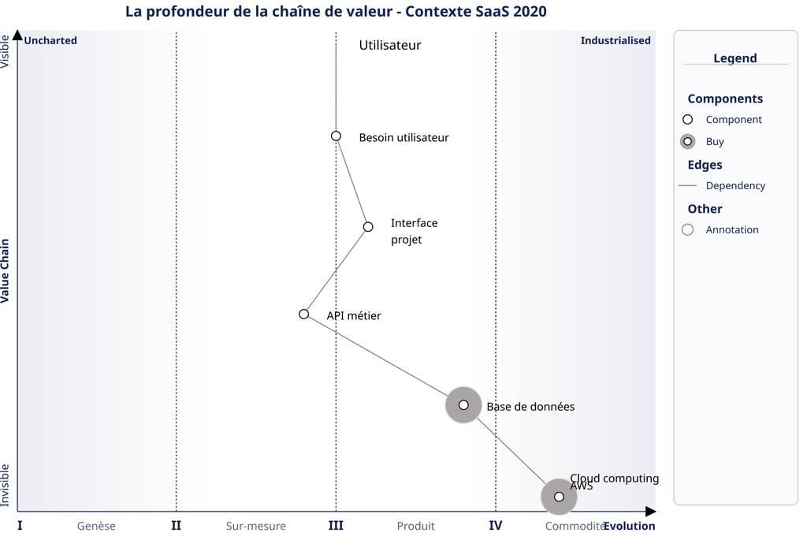

Plusieurs événements transforment radicalement le paysage :

**Réglementaire :**

- La directive **NIS2**[^16] (échéance de transposition en octobre 2024) impose des obligations de sécurité strictes, poussant de fait vers un contrôle accru de la chaîne de sous-traitance et de l’hébergement
- Le **Data Act** européen impose la portabilité et facilite le changement de fournisseur pour les données hébergées[^17]
- Les certifications **SecNumCloud**[^18] deviennent un prérequis pour les marchés publics

**Commercial :**

- Un grand compte français refuse de signer : « Nous exigeons un hébergement en France avec certification SecNumCloud »
- Un appel d’offres européen écarte votre proposition : « Cloud américain non conforme RGPD renforcé »
- Votre RSSI (Responsable de la sécurité des systèmes d’information) reçoit une mise en demeure de l’ANSSI[^19] : « Audit obligatoire de vos sous-traitants cloud »

**Concurrentiel :** - Un concurrent lance une offre « 100% souverain » et gagne 3 grands comptes - Les argumentaires commerciaux changent : « Hébergé en France » devient le premier critère

Soudain, **le cloud n’est plus invisible**.

#### La carte révèle le changement

La carte révèle maintenant de **nouveaux chemins de visibilité** :

**Besoin utilisateur** → **Conformité réglementaire** → **Cloud computing** **Besoin utilisateur** → **Argumentaire commercial** → **Cloud computing**

Le cloud computing passe de **quatre sauts à un ou deux sauts**. Il n’est plus un composant d’infrastructure invisible. Il devient : - Un **critère de sélection** dans l’argumentaire commercial - Un **risque de conformité** scruté par le RSSI et le DPO (délégué à la protection des données) - Un **différenciateur concurrentiel** face aux acteurs souverains

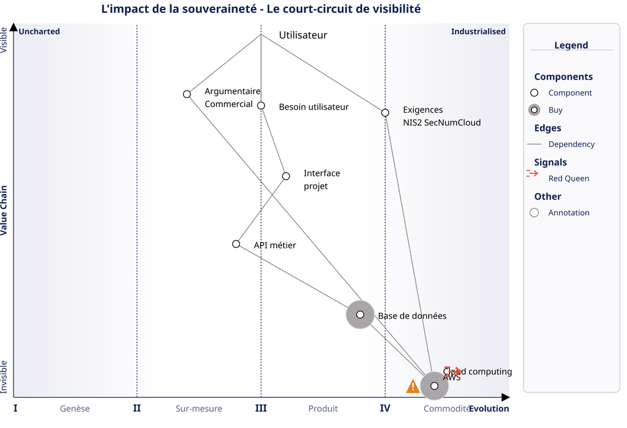

#### Pourquoi cette distinction est stratégique

Ce changement de visibilité transforme radicalement les décisions stratégiques.

**Quand le cloud était invisible (4 sauts) :** - Décision technique : « On prend AWS, c’est le plus mature » - Critère : Performance, coût, fiabilité - Responsable : CTO - Budget : Optimisation continue du coût cloud

**Quand le cloud devient visible (1-2 sauts) :** - Décision stratégique : « Migrer vers OVH/Scaleway ou perdre des marchés ? » - Critère : Souveraineté, conformité, différenciation commerciale - Responsables : CEO, directeur commercial, RSSI, DPO - Budget : Migration = 6 mois de dev + risque technique vs gain commercial potentiel

**Les implications deviennent majeures :**

**Commercial :** Le cloud n’est plus un détail technique dans le slide 47 de la présentation commerciale. C’est dans le pitch, sur la homepage. « Hébergé en France, certifié SecNumCloud » devient un argument de vente de premier plan. Vous perdez ou gagnez des appels d’offres sur ce critère.

**Réglementaire :** Une panne AWS n’est plus un simple incident technique. C’est un risque de non-conformité NIS2, potentiellement sanctionnable. Le RSSI doit pouvoir justifier chaque choix devant l’ANSSI.

**Concurrentiel :** Vos concurrents européens qui ont migré tôt vers le souverain ont un avantage compétitif temporaire. Plus vous attendez, plus vous perdez des parts de marché.

**Financier :** Migration OVH = 300k€ + 6 mois. Mais un grand compte perdu = 500k€/an de MRR[^20]. L’équation n’est plus technique, elle est business.

#### La carte comme outil de projection

La puissance de cette approche réside dans l’**anticipation**. Si en 2022 vous aviez tracé sur votre carte les composants « Conformité réglementaire » et « Argumentaire commercial » (même s’ils n’étaient pas encore critiques), vous auriez **vu venir** le changement de visibilité du cloud.

Vous auriez pu : - Créer une **couche d’abstraction** « Infrastructure cloud » dès le début, facilitant une migration future - Négocier avec AWS un plan de migration vers AWS Europe avec garanties souveraineté - Anticiper le basculement vers OVH/Scaleway avant que la pression commerciale ne devienne critique

**Le contexte change la visibilité. La carte révèle ces changements avant qu’ils ne deviennent des crises.**

#### La limite du tableau blanc

Sur un tableau blanc, nous sommes contraints de représenter les composants en **pile verticale**. C’est un compromis pratique : facile à dessiner, facile à comprendre, suffisant pour la plupart des discussions stratégiques. Le tableau blanc reste l’outil de co-construction par excellence : rien ne remplace le fait de dessiner ensemble, d’effacer, de redessiner, de pointer du doigt, de débattre autour d’un croquis partagé.

Mais cette représentation physique a un biais : elle suggère que la position verticale **est** la visibilité, alors qu’en réalité la visibilité devrait être calculée dynamiquement : le **chemin le plus court** entre le repère et chaque composant.

Les **outils numériques** apportent ici une vraie valeur ajoutée. Ils ne remplacent pas le tableau blanc, ils le complètent. Après la session de co-construction, un logiciel de cartographie peut calculer automatiquement le nombre de sauts pour chaque composant et repositionner verticalement les éléments selon leur visibilité réelle.

Il peut mettre en évidence (par la couleur, la taille, ou l’opacité) les composants dont la visibilité change lorsqu’on découvre de nouveaux liens. Il peut alerter lorsqu’un composant que vous aviez classé comme « infrastructure invisible » se révèle être directement exposé aux utilisateurs via un chemin que vous n’aviez pas vu.

Le tableau blanc pour la co-construction, le numérique pour l’analyse : voilà la complémentarité vertueuse. En attendant, si vous travaillez uniquement au tableau blanc, gardez cette règle heuristique : **la visibilité d’un composant, c’est le nombre minimum de liens qui le séparent du repère**. Quand vous positionnez un composant « en bas » de la carte, posez-vous systématiquement la question : « Existe-t-il un chemin plus court que je n’ai pas vu ? »

Cette question (simple en apparence) peut révéler des dépendances cachées et transformer votre compréhension stratégique du système.

## Conclusion : la carte comme synthèse de notre voyage

Nous voici arrivés à un moment charnière de ce livre. Avec la carte de Wardley, nous possédons enfin l’outil qui relie tous les fils que nous avons tissés jusqu’ici.

Dans la **Partie I**, nous avons exploré le paysage concurrentiel, ce terrain mouvant où les organisations luttent pour survivre et prospérer. Nous avons compris que la stratégie n’est pas un plan figé mais une navigation constante dans l’incertitude. La carte nous donne maintenant les moyens de **représenter ce paysage**, de le rendre visible et partageable, de le discuter collectivement plutôt que de l’imaginer chacun dans son coin.

Dans la **Partie II**, nous avons examiné comment les organisations font face au mouvement : leurs structures, leurs doctrines, leurs modes de décision. Nous avons vu les pièges du théâtre de la stratégie, où les egos transforment chaque débat en bataille de territoire. La carte offre un **antidote à ce théâtre** : un langage commun qui déplace la conversation du « qui a raison ? » vers « qu’observons-nous ensemble ? ».

Dans la **Partie III**, nous avons découvert les lois du mouvement : l’évolution inéluctable des composants, les forces qui poussent la genèse vers la commodité, les patterns qui se répètent d’un secteur à l’autre. La carte **intègre ces lois** dans sa structure même : l’axe horizontal n’est pas une échelle arbitraire, c’est la matérialisation de l’évolution que nous avons étudiée au chapitre 5.

Et maintenant, dans cette **Partie IV**, nous apprenons à pratiquer. La carte n’est plus un concept abstrait : c’est un outil que vous pouvez tracer demain, avec votre équipe, sur votre tableau blanc. C’est un langage que vous pouvez apprendre, affiner, maîtriser.

Mais la carte seule ne suffit pas. Elle révèle le terrain, elle rend visible le mouvement, elle structure la conversation. Reste à **agir** sur ce terrain. Comment identifier les patterns récurrents qui guident les décisions ? Comment reconnaître les signaux faibles qui annoncent les disruptions ? Comment transformer l’observation en action stratégique ?

C’est ce que nous explorerons dans les chapitres suivants, où nous passerons de la carte au mouvement (de la représentation à l’action).

[^1]: La distinction entre problème algorithmique et heuristique s’appuie sur les travaux de Herbert A. Simon sur la rationalité limitée (*bounded rationality*). Voir Herbert A. Simon, *The Sciences of the Artificial*, MIT Press, 1969. Simon Wardley reprend explicitement cette distinction dans sa méthode de cartographie.
[^2]: Concept popularisé par Sean Ellis, fondateur de GrowthHackers.com. Voir Sean Ellis et Morgan Brown, *Hacking Growth*, Crown Business, 2017.
[^3]: Les cartes de Wardley (*Wardley Maps*) sont issues des travaux de Simon Wardley, publiés sous licence Creative Commons Attribution-ShareAlike 4.0 International (CC BY-SA 4.0). Source : Simon Wardley, *Wardley Maps*, 2016-présent, disponible sur medium.com/@swardley. Elle a ses limites, ses approximations, ses zones d’ombre. Mais au moment où ce livre est écrit, c’est la seule représentation qui intègre explicitement l’évolution des composants dans une chaîne de valeur, et donc la meilleure dont nous disposons pour discuter stratégie et appliquer des heuristiques de manière structurée.
[^4]: Le mouvement *Software Craftsmanship* a été formalisé par le *Manifesto for Software Craftsmanship* (2009), dans la lignée d’Andrew Hunt et David Thomas, *The Pragmatic Programmer*, Addison-Wesley, 1999, et théorisé par Robert C. Martin dans *The Clean Coder*, Prentice Hall, 2011.
[^5]: Snyk (snyk.io, fondé en 2015 par Guy Podjarny) est une plateforme de sécurité applicative. Dependabot a été acquis et intégré par GitHub en 2019 (docs.github.com).
[^6]: Règlement (UE) 2016/679 du 27 avril 2016 (Règlement général sur la protection des données), applicable depuis le 25 mai 2018.
[^7]: SOC 2 (*Service Organization Control* 2) est un cadre d’audit (et non une réglementation) défini par l’AICPA (*American Institute of Certified Public Accountants*). Il évalue les contrôles de sécurité, disponibilité, intégrité, confidentialité et respect de la vie privée des prestataires de services.
[^8]: Les *design patterns* ont été formalisés par Erich Gamma, Richard Helm, Ralph Johnson et John Vlissides (le « Gang of Four »), *Design Patterns: Elements of Reusable Object-Oriented Software*, Addison-Wesley, 1994. Les principes SOLID ont été formulés par Robert C. Martin (acronyme introduit par Michael Feathers) ; voir R. C. Martin, *Agile Software Development: Principles, Patterns, and Practices*, Prentice Hall, 2002. L’architecture hexagonale (*Ports and Adapters*) a été proposée par Alistair Cockburn en 2005.
[^9]: GitHub Copilot a été lancé en *preview* technique en juin 2021, puis en disponibilité générale en juin 2022 (blog.github.com). Cursor a été fondé par Anysphere Inc. en 2023 (cursor.com). Claude Code a été lancé par Anthropic en 2025 (anthropic.com).
[^10]: Créé par Linus Torvalds en 2005. Selon le *Stack Overflow Developer Survey* (2023), Git est utilisé par plus de 93 % des développeurs professionnels.
[^11]: GPT-4 a été lancé par OpenAI via API en mars 2023. Début 2025, la guerre des prix entre OpenAI, Anthropic, Google et Mistral a drastiquement fait chuter les coûts au token. La convergence des performances est documentée par des classements indépendants tels que la LMSYS Chatbot Arena (lmsys.org).
[^12]: Fondé en 2006 par Tobias Lütke, Shopify équipe aujourd’hui des millions de marchands. Selon les données BuiltWith (2024), Shopify est l’une des technologies e-commerce les plus déployées au monde.
[^13]: Estimations indicatives à visée illustrative. Un développeur web interne coûte en moyenne entre 50k€ et 70k€ (salaire brut, hors charges patronales, selon les études de rémunération tech en France), là où une stack SaaS standardisée (Shopify, Stripe) pour une PME représente un budget annuel marginal de quelques milliers d’euros.
[^14]: Outils communautaires accessibles en ligne : OnlineWardleyMaps (onlinewardleymaps.com, créé par Ben Mosior), Atlas² (atlas2.wardleymaps.com).
[^15]: Concept issu de l’aéronautique, formalisé par Mica R. Endsley (« Toward a Theory of Situation Awareness in Dynamic Systems », *Human Factors*, vol. 37, n° 1, 1995, p. 32-64), et transposé à la stratégie d’entreprise par Simon Wardley dans sa série d’articles « On being lost », Medium, 2016-2017.
[^16]: Directive (UE) 2022/2555 du Parlement européen et du Conseil du 14 décembre 2022 (Journal officiel de l’Union européenne, L 333, 27.12.2022). La date limite de transposition en droit national était le 17 octobre 2024.
[^17]: Règlement (UE) 2023/2854 du Parlement européen et du Conseil du 13 décembre 2023 (Data Act). Le chapitre VI porte spécifiquement sur la facilitation du changement de fournisseur de services de traitement de données, applicable à partir de septembre 2025.
[^18]: Référentiel SecNumCloud de l’ANSSI (version 3.2, 2022). La doctrine « Cloud au centre » de l’État français (circulaire n° 6282/SG du 5 juillet 2021, actualisée en mai 2023) impose le recours à des offres qualifiées SecNumCloud pour les données sensibles de l’État.
[^19]: ANSSI (Agence nationale de la sécurité des systèmes d’information), autorité française de cybersécurité créée par le décret n° 2009-834 du 7 juillet 2009, et autorité compétente pour la transposition de NIS2 en France.
[^20]: MRR (*Monthly Recurring Revenue*, revenu récurrent mensuel). Chiffres illustratifs basés sur les ordres de grandeur habituels observés lors de refontes d’infrastructures pour des éditeurs SaaS de 20 à 50 collaborateurs.

v2.16.0-beta